# Лабораторная работа № 7

Дискретно-событийное моделирование: M/M/c и модель Росса

Талебу Тенке Франк

2026-11-01

# Информация

## Докладчик

- **Талебу Тенке Франк**
- **Студенческий билет:** 1032224534
- Российский университет дружбы народов имени Патриса Лумумбы
- Дисциплина: Имитационное моделирование
- Лабораторная работа № 7

# Вводная часть

## Актуальность

- Дискретно-событийное моделирование описывает систему через последовательность событий.
- Системы массового обслуживания позволяют изучать очереди и загрузку ресурсов.
- Модели ремонта помогают исследовать надёжность работы оборудования.

## Объект и предмет исследования

- **Объект:** системы массового обслуживания и ремонта машин.
- **Предмет:** время ожидания, загрузка обслуживающих каналов, резервные машины и динамика отказов.

## Цели и задачи

**Цель:** изучить методы дискретно-событийного моделирования и применить их к системам обслуживания и ремонта.

- Реализовать модель M/M/c в структуре DrWatson и построить графики.
- Реализовать модель Росса с несколькими ремонтниками.
- Исследовать разные количества машин.
- Оценить загрузку ремонтников, очередь и число исправных машин.
- Сопоставить результаты с аналитическим решением.

## Материалы и методы

- **Julia:** реализация программ моделирования.
- **DrWatson:** организация структуры проекта.
- **M/M/c:** поток заявок и несколько параллельных каналов обслуживания.
- **Модель Росса:** отказы, резервные машины и ремонтные ресурсы.
- **Графики:** анализ результатов моделирования.

# Ход выполнения работы

## Теоретическая модель M/M/c

- Первая буква **M** означает пуассоновский поток заявок.
- Вторая **M** означает экспоненциальное время обслуживания.
- **c** — число параллельных каналов обслуживания.
- Основные параметры: интенсивность поступления λ и обслуживания μ.

## выполнение

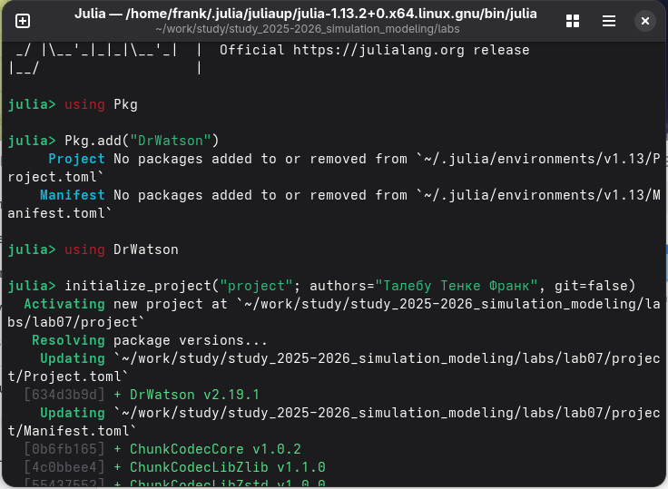

## выполнение

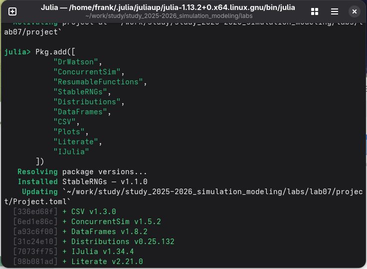

## выполнение

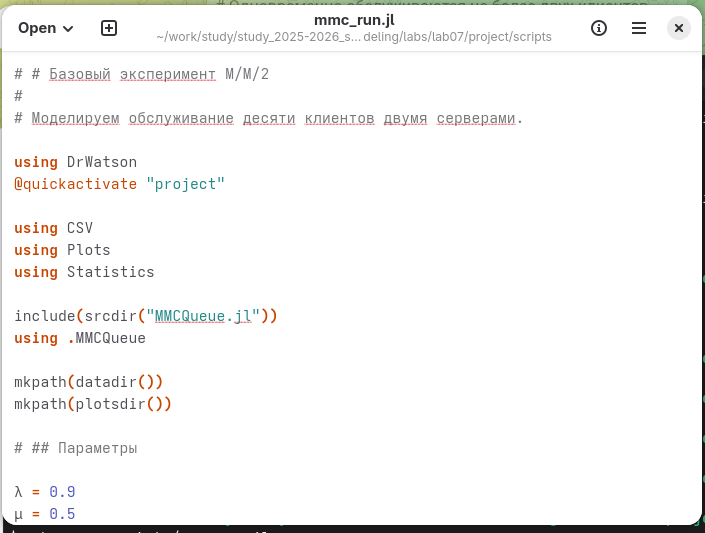

## выполнение

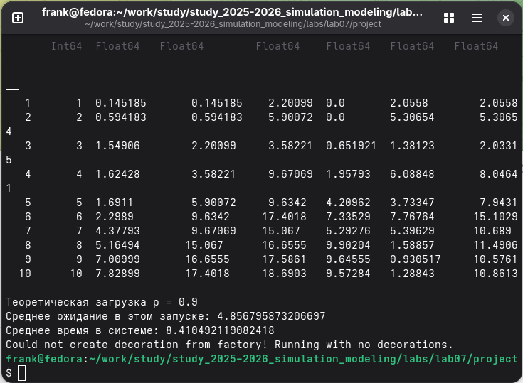

## выполнение

[figure not shown]

## выполнение

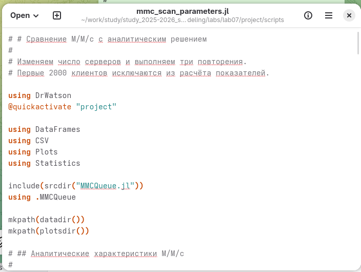

## выполнение

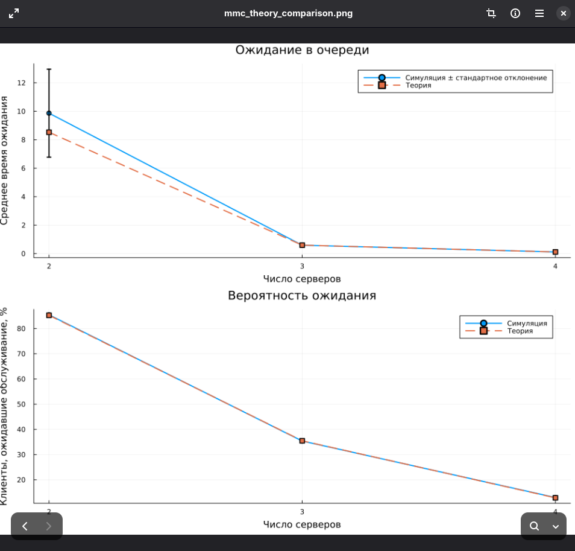

## выполнение

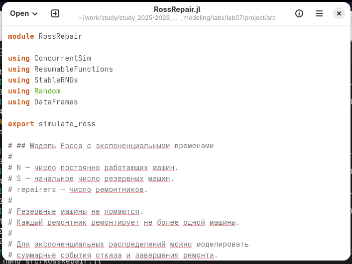

## выполнение

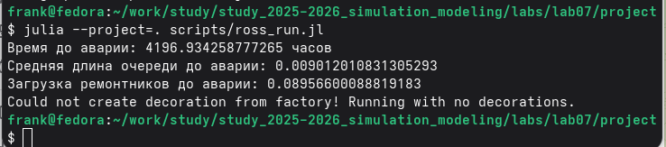

## выполнение

[figure not shown]

## выполнение

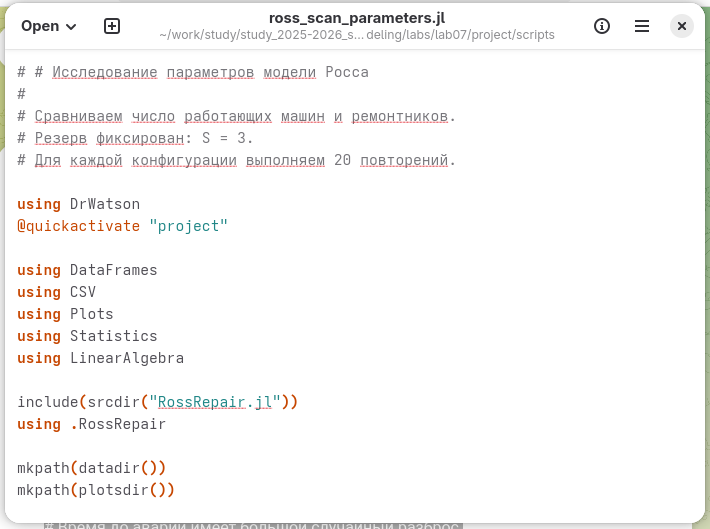

## выполнение

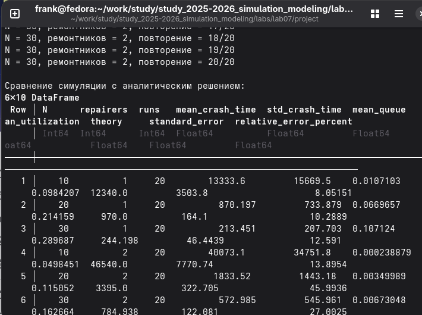

## выполнение

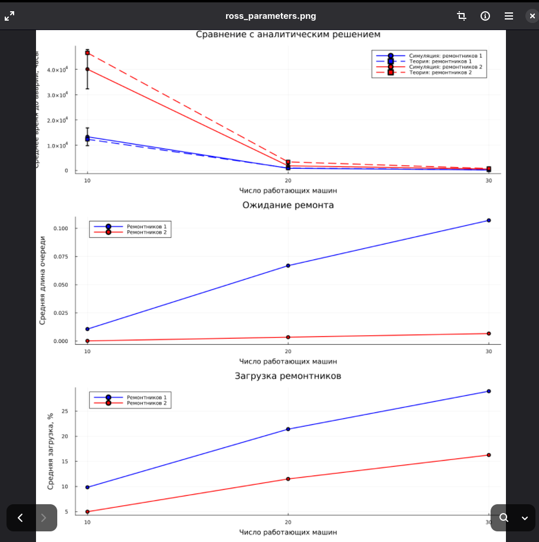

# Результаты и обсуждение

## Основные результаты

- Рассмотрены модели **M/M/c** и **Росса**.
- Реализованы сценарии запуска на Julia.
- Получены консольные результаты и графики обеих моделей.
- Изучены особенности систем с очередями и резервными машинами.

# Заключение

## Выводы

- Дискретно-событийный подход подходит для анализа очередей и отказов оборудования.
- Модель M/M/c описывает обслуживание заявок несколькими каналами.
- Модель Росса описывает систему машин, резерва и ремонта.
- Графики помогают исследовать динамику работы моделируемых систем.

## Спасибо за внимание!